# Final Project

Prithvi Rana

November 15

# Set Up

### Clean up environment and load packages

```r
# clean up the RStudio environment
rm(list = ls())

# load all packages here: `mosaic`, `tidyverse`, `lubridate`, and all others used

library(DataComputing)
library(mosaic)
library(tidyverse)
library(gridExtra)
```

### Are the significant causes of Amazon Rainforest Deforestation natural or unnatural?

### Background of Dataset

- This project will primarily make use of Brazilian Amazon Rainforest Degradation 1999-2019 Dataset
- It was found on Kaggle
- This is a publicly available dataset maintained by Mariana Boger Netto
- The dataset was created in 2019 with the purpose of understanding Amazon deforestation
- The dataset contains 3 files

### Primary Data

inpebrazilianamazonfires1999_2019 case represents the amount of fire outbreaks in Amazon by State, month, year from 1999 - 2019 with their location.

Total Cases: 2104

```r
amazon_fires <- read.csv("inpe_brazilian_amazon_fires_1999_2019.csv")

nrow(amazon_fires)
```

```
[1] 2104
```

```r
str(amazon_fires)
```

```
'data.frame':   2104 obs. of  6 variables:
 $ year     : int  1999 1999 1999 1999 1999 1999 1999 1999 1999 1999 ...
 $ month    : int  1 1 1 1 1 1 2 2 2 2 ...
 $ state    : chr  "AMAZONAS" "MARANHAO" "MATO GROSSO" "PARA" ...
 $ latitude : num  -2.37 -2.26 -12.66 -2.47 -12.86 ...
 $ longitude: num  -59.9 -45.5 -55.1 -48.5 -60.5 ...
 $ firespots: int  3 36 18 87 1 15 1 43 8 285 ...
```

### Support Data

defarea2004_2019 case represents the deforestation area (km sq) by year and state from 2004 - 2019.

Total Cases: 16

```r
def_area <- read.csv("def_area_2004_2019.csv")
nrow(def_area)
```

```
[1] 16
```

```r
glimpse(def_area)
```

```
Rows: 16
Columns: 11
$ ï..Ano.Estados <int> 2004, 2005, 2006, 2...
$ AC             <int> 728, 592, 398, 184,...
$ AM             <int> 1232, 775, 788, 610...
$ AP             <int> 46, 33, 30, 39, 100...
$ MA             <int> 755, 922, 674, 631,...
$ MT             <int> 11814, 7145, 4333, ...
$ PA             <int> 8870, 5899, 5659, 5...
$ RO             <int> 3858, 3244, 2049, 1...
$ RR             <int> 311, 133, 231, 309,...
$ TO             <int> 158, 271, 124, 63, ...
$ AMZ.LEGAL      <int> 27772, 19014, 14286...
```

elninolanina1999_2019 case represents data about the start year, end year and severity of 2 of the most important climatic phenomenon in Brazil i.e the El Nino and El Nina which are known to affect the frequency of forest fires.

Total Cases: 16

```r
elnino_elnina <- read.csv("el_nino_la_nina_1999_2019.csv")

nrow(elnino_elnina)
```

```
[1] 16
```

```r
glimpse(elnino_elnina)
```

```
Rows: 16
Columns: 4
$ ï..start.year <int> 2004, 2006, 2014, 20...
$ end.year      <int> 2005, 2007, 2015, 20...
$ phenomenon    <chr> "El Nino", "El Nino"...
$ severity      <chr> "Weak", "Weak", "Wea...
```

### Variables for Analysis

I plan to use variables from three different data tables. Year,latitude,longitude,severity,firespots among others.

### EDA plots

```r
head(amazon_fires)
```

|  | year | month | state | latitude | longitude | firespots |
| --- | --- | --- | --- | --- | --- | --- |
| 1 | 1999 | 1 | AMAZONAS | -2.371113 | -59.89993 | 3 |
| 2 | 1999 | 1 | MARANHAO | -2.257395 | -45.48783 | 36 |
| 3 | 1999 | 1 | MATO GROSSO | -12.660633 | -55.05799 | 18 |
| 4 | 1999 | 1 | PARA | -2.474820 | -48.54697 | 87 |
| 5 | 1999 | 1 | RONDONIA | -12.861700 | -60.51310 | 1 |
| 6 | 1999 | 1 | RORAIMA | 3.403225 | -60.62285 | 15 |

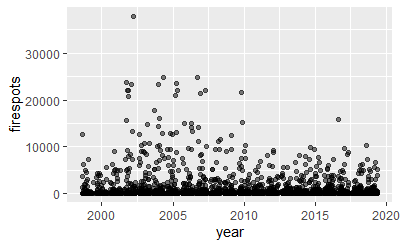

```r
amazon_fires %>%
  ggplot(aes(x=year, y=firespots))+
  geom_point(alpha = 0.5, position = "jitter")
```

There seems to be a concentration of firespots in the years of 2003-2005

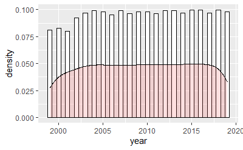

```r
amazon_fires %>%
  ggplot(aes(x=year)) +
    geom_histogram(aes(y=..density..),
                   binwidth=.5,
                   colour="black", fill="white") +
    geom_density(alpha=.2, fill="#FF6666")
```

```r
head(elnino_elnina)
```

|  | ï..start.year | end.year | phenomenon | severity |
| --- | --- | --- | --- | --- |
| 1 | 2004 | 2005 | El Nino | Weak |
| 2 | 2006 | 2007 | El Nino | Weak |
| 3 | 2014 | 2015 | El Nino | Weak |
| 4 | 2018 | 2019 | El Nino | Weak |
| 5 | 2002 | 2003 | El Nino | Moderate |
| 6 | 2009 | 2010 | El Nino | Moderate |

```r
str(elnino_elnina)
```

```
'data.frame':   16 obs. of  4 variables:
 $ ï..start.year: int  2004 2006 2014 2018 2002 2009 2015 2000 2005 2008 ...
 $ end.year     : int  2005 2007 2015 2019 2003 2010 2016 2001 2006 2009 ...
 $ phenomenon   : chr  "El Nino" "El Nino" "El Nino" "El Nino" ...
 $ severity     : chr  "Weak" "Weak" "Weak" "Weak" ...
```

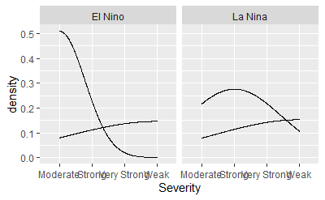

```r
elnino_elnina %>%
  ggplot(aes(x=severity))+
  geom_density()+
  facet_wrap(~phenomenon)+
  xlab("Severity")
```

```r
NA
```

The above plot gives us an idea of the severity of the phenomenon. My initial guess is that these phenomenon do not play a significant role in deforestation. However, we will have to wait and see what kind of plots we get when we graph them against forest fire outbreaks and deforestation

### Forest Fire outbreak analysis

Now, we need to see the months in which there is a concentration of forest fires.

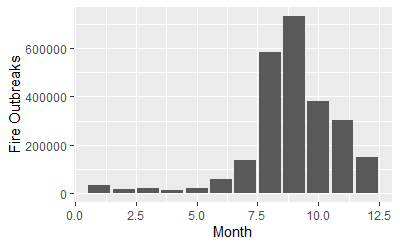

```r
amazon_fires%>%
  ggplot(aes(x=month,y=firespots))+
  geom_bar(stat='identity')+
  scale_y_continuous(labels=function(n){format(n, scientific = FALSE)})+
  ylab("Fire Outbreaks")+
  xlab("Month")
```

```r
NA
NA
```

We can see from the graph that the months with the most outbreaks are 8,9,10 i.e August, September and October.

El Niño and La Niña episodes typically last 9-12 months. They both tend to develop during the spring (March-June), reach peak intensity during the late autumn or winter (November-February), and then weaken during the spring or early summer (March-June)"

source - https://www.climate.gov/news-features/understanding-climate/el-ni%C3%B1o-and-la-ni%C3%B1a-frequently-asked-questions

Our data is telling us that the peak fire outbreak frequency occurs in the months where the El Nino and El Nina are not at their peak intensity. This indicates that the fires may have an unnatural source.

### Fire Outbreaks in Each State

We need to see if our results are being skewed by one or two states with high number of outbreaks or if they are equally distributed over brazil.

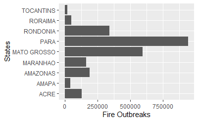

```r
amazon_fires%>%
  ggplot(aes(y=state, x=firespots))+
  geom_bar(stat='identity')+
  xlab("Fire Outbreaks")+
  ylab("States")
```

Our hunch was correct. Para, Mato Grosso and Rondonia account for the majority of fire outbreaks. Where Para has had more than double the number of fires than any other state except for Mato Grosso.

To get an even clearer picture of the fire outbreaks in each state, we will plot them all together for a side-by-side comparison.

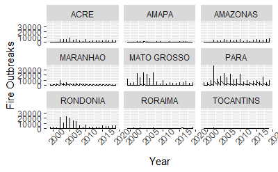

```r
amazon_fires%>%
  ggplot(aes(x=year, y=firespots))+
  geom_line()+
  facet_wrap(~state)+
  theme(axis.text.x = element_text(angle=45))+
  ylab("Fire Outbreaks")+
  xlab("Year")
```

### Fire outbreaks and Deforestation

We want to see the correlation between deforestation and fire outbreaks.

First, we need to see what the overall trend for deforestation is in the Amazon.

```r
head(def_area)
```

|  | ï..Ano.Estados | AC | AM | AP | MA | MT | PA | RO | RR | TO | AMZ.LEGAL |
| --- | --- | --- | --- | --- | --- | --- | --- | --- | --- | --- | --- |
| 1 | 2004 | 728 | 1232 | 46 | 755 | 11814 | 8870 | 3858 | 311 | 158 | 27772 |
| 2 | 2005 | 592 | 775 | 33 | 922 | 7145 | 5899 | 3244 | 133 | 271 | 19014 |
| 3 | 2006 | 398 | 788 | 30 | 674 | 4333 | 5659 | 2049 | 231 | 124 | 14286 |
| 4 | 2007 | 184 | 610 | 39 | 631 | 2678 | 5526 | 1611 | 309 | 63 | 11651 |
| 5 | 2008 | 254 | 604 | 100 | 1271 | 3258 | 5607 | 1136 | 574 | 107 | 12911 |
| 6 | 2009 | 167 | 405 | 70 | 828 | 1049 | 4281 | 482 | 121 | 61 | 7464 |

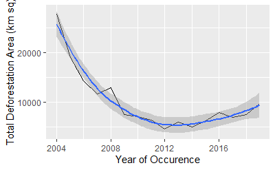

```r
def_area %>%
  ggplot(aes(x=ï..Ano.Estados, y=AMZ.LEGAL))+
  geom_line()+
  geom_smooth()+
  xlab("Year of Occurence")+
  ylab("Total Deforestation Area (km sq)")
```

After 2012, the fire outbreaks mostly correlate with the deforestation data. However, not perfectly. Which means fire outbreaks are not the only form of deforestation that is happening in the amazon. Any other form of deforestation would have to be done by human hands.

### Trends in Fire outbreaks over the years

```r
Recent <- amazon_fires %>%
  filter(year > 2014 ) %>%
  summarise(Avg_fireoutbreaks_recent = mean(firespots))

Historic <- amazon_fires %>%
  summarise(Avg_fireoutbreaks_historic = mean(firespots))

Middle <- amazon_fires %>%
  filter(year > 2008 & year < 2014 ) %>%
  summarise(Avg_fireoutbreaks_middlec = mean(firespots))

crossing(Historic, Middle, Recent)
```

| Avg_fireoutbreaks_historic | Avg_fireoutbreaks_middlec | Avg_fireoutbreaks_recent |
| --- | --- | --- |
| 1167.418 | 815.3184 | 880.9962 |

```r
NA
```

As we can see, historically there have been a lot of forest fires in an average year. The historical average is so high because of the early years of the data i.e 1999 to 2008,when there was high fire outbreak frequency. The middle i.e the years between 2008 and 2014 showcase a considerable drop. The recent times i.e the years between 2014 and 2019 have a higher fire outbreak average. This sudden increase in fire outbreaks is what many in the scientific community believe comes from human interference for the most part.

```r
amazon_fires %>%
  group_by(year) %>%
  summarise(Totalfires = sum(firespots))%>%
  arrange(desc(Totalfires))
```

| year | Totalfires |
| --- | --- |
| 2002 | 273873 |
| 2004 | 218637 |
| 2005 | 213720 |
| 2007 | 186480 |
| 2003 | 174400 |
| 2006 | 144422 |
| 2010 | 134614 |
| 2017 | 107439 |
| 2015 | 106438 |
| 2008 | 103453 |

[output cut: 11 more lines]

Here we can explicitly see the total number of forest fires and which years have the most number of fires in the dataset. 2002, 2004 and 2005 were the most fiery years in the Amazon.

### El Nino - La Nina Analysis

We need to analyse the trends in fire outbreaks while taking into account the El Nino - La Nina weather phenomena.

```r
#Join Operation
weatherandfire <-
  left_join(elnino_elnina, amazon_fires, by =c("ï..start.year" = "year"))

weatherandfire
```

| ï..start.year | end.year | phenomenon | severity | month | state | latitude | longitude | firespots |
| --- | --- | --- | --- | --- | --- | --- | --- | --- |
| 2004 | 2005 | El Nino | Weak | 1 | AMAPA | 1.318621e-01 | -51.64209 | 58 |
| 2004 | 2005 | El Nino | Weak | 1 | AMAZONAS | -7.619639e-01 | -64.50315 | 277 |
| 2004 | 2005 | El Nino | Weak | 1 | MARANHAO | -3.133702e+00 | -45.98556 | 242 |
| 2004 | 2005 | El Nino | Weak | 1 | MATO GROSSO | -1.242806e+01 | -55.52833 | 171 |
| 2004 | 2005 | El Nino | Weak | 1 | PARA | -2.370078e+00 | -50.86759 | 875 |
| 2004 | 2005 | El Nino | Weak | 1 | RONDONIA | -1.177026e+01 | -63.30655 | 31 |
| 2004 | 2005 | El Nino | Weak | 1 | RORAIMA | 2.321239e+00 | -60.24496 | 522 |
| 2004 | 2005 | El Nino | Weak | 1 | TOCANTINS | -6.374500e+00 | -48.18950 | 2 |
| 2004 | 2005 | El Nino | Weak | 2 | ACRE | -8.150750e+00 | -72.61125 | 4 |
| 2004 | 2005 | El Nino | Weak | 2 | AMAPA | 6.860000e-01 | -50.98700 | 1 |

[output cut: 990 more lines]

```r
NA
```

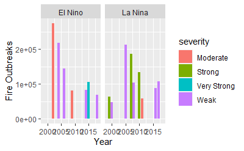

```r
weatherandfire %>%
  ggplot(aes(x=ï..start.year,y=firespots, fill = severity))+
  facet_wrap(~phenomenon)+
  geom_bar(stat='identity')+
  xlab("Year")+
  ylab("Fire Outbreaks")
```

When we examine the El Nino - La Nina severity with the fire outbreaks, we see that there is not a lot correlation. The largest fire outbreak occurred when the El Nino phenomenon was just classified as “Moderate” while plenty of the “Weak” years showcase large outbreaks

But we do know that this phenomena has an impact on forest fires. There is a possibility that people are setting fires in the amazon forest during the years when the phenomena is weak which is throwing off something that should be a correlation.

```r
# For-loop to change severity from category to number by explicit assignment

for (i in seq_along(elnino_elnina$severity)) {
  if(!is.null(elnino_elnina$severity[[i]]) & elnino_elnina$severity[[i]] == "Weak"){
    elnino_elnina$severity[[i]] = 1
  }
  else if(!is.null(elnino_elnina$severity[[i]]) & elnino_elnina$severity[[i]] == "Moderate"){
    elnino_elnina$severity[[i]] = 2
  }
  else if(!is.null(elnino_elnina$severity[[i]]) & elnino_elnina$severity[[i]] == "Strong"){
    elnino_elnina$severity[[i]] = 3
  }
  else if(!is.null(elnino_elnina$severity[[i]]) & elnino_elnina$severity[[i]] == "Very Strong"){
    elnino_elnina$severity[[i]] = 4
  }

}

#Converting datatype from string to int
elnino_elnina$severity <- as.numeric(elnino_elnina$severity)
```

```r
# Temp dataframe
placeholder <- elnino_elnina

#Spread
spreadphenom <- placeholder %>%
  spread(key = phenomenon, value = severity)

weatheranddefor <-
  left_join(spreadphenom, def_area, by =c("ï..start.year" = "ï..Ano.Estados"))

weatheranddefor[is.na(weatheranddefor)] <- 0

weatheranddefor
```

| ï..start.year | end.year | El Nino | La Nina | AC | AM | AP | MA | MT | PA | RO | RR | TO | AMZ.LEGAL |
| --- | --- | --- | --- | --- | --- | --- | --- | --- | --- | --- | --- | --- | --- |
| 1999 | 2000 | 0 | 3 | 0 | 0 | 0 | 0 | 0 | 0 | 0 | 0 | 0 | 0 |
| 2000 | 2001 | 0 | 1 | 0 | 0 | 0 | 0 | 0 | 0 | 0 | 0 | 0 | 0 |
| 2002 | 2003 | 2 | 0 | 0 | 0 | 0 | 0 | 0 | 0 | 0 | 0 | 0 | 0 |
| 2004 | 2005 | 1 | 0 | 728 | 1232 | 46 | 755 | 11814 | 8870 | 3858 | 311 | 158 | 27772 |
| 2005 | 2006 | 0 | 1 | 592 | 775 | 33 | 922 | 7145 | 5899 | 3244 | 133 | 271 | 19014 |
| 2006 | 2007 | 1 | 0 | 398 | 788 | 30 | 674 | 4333 | 5659 | 2049 | 231 | 124 | 14286 |
| 2007 | 2008 | 0 | 3 | 184 | 610 | 39 | 631 | 2678 | 5526 | 1611 | 309 | 63 | 11651 |
| 2008 | 2009 | 0 | 1 | 254 | 604 | 100 | 1271 | 3258 | 5607 | 1136 | 574 | 107 | 12911 |
| 2009 | 2010 | 2 | 0 | 167 | 405 | 70 | 828 | 1049 | 4281 | 482 | 121 | 61 | 7464 |
| 2010 | 2011 | 0 | 3 | 259 | 595 | 53 | 712 | 871 | 3770 | 435 | 256 | 49 | 7000 |

[output cut: 6 more lines]

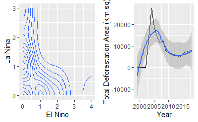

```r
plot1 <- weatheranddefor %>%
  ggplot(aes(x = `El Nino`, y =`La Nina`))+
  geom_density2d()

plot2 <- weatheranddefor %>%
  ggplot(aes(x = ï..start.year, y = AMZ.LEGAL))+
  geom_line()+
  geom_smooth()+
  xlab("Year")+
  ylab("Total Deforestation Area (km sq)")


grid.arrange(plot1, plot2, nrow=1, ncol=2)
```

```r
NA
```

### Conclusion

Given the many evidences we have evaluated regarding deforestation, fire outbreaks and the weather phenomena of the Amazon. I think we can confidently say that the cause of rising deforestation in the Amazon in recent years is unnatural.

I hope this insight can help us understand the magnitude of the current situation.